# Home

## Home tabs

### Welcome

This website shows real-time data from monitoring programs in Lake Champlain and throughout the Lake Champlain Basin.

Please choose a data type above. All data plots are interactive.

**This website is in development. All data is provisional and for educational purposes only.**

Last updated 2026-10-31 18:30:38

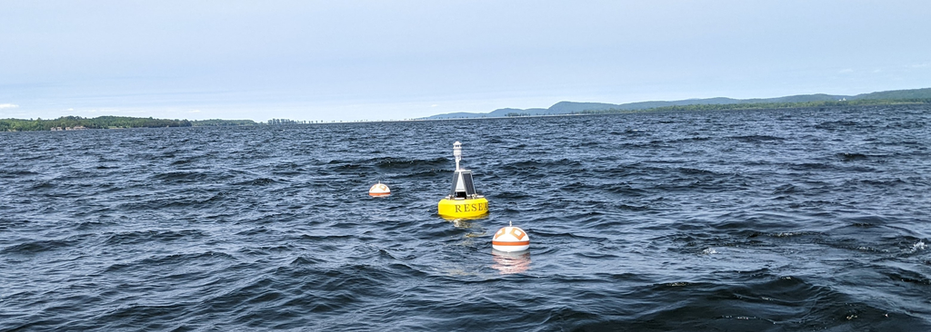

### Info

Lake Champlain level, lake temperature, and tributary discharge data is collected by the [US Geological Survey](https://dashboard.waterdata.usgs.gov/).

The Lamoille River and Malletts Bay buoys are part of a pilot study to upgrade and modernize the [Lake Champlain Long-term Monitoring Program](https://dec.vermont.gov/watershed/lakes-ponds/monitor/lake-champlain). They are instrumented with an array of water quality and weather sensors that measure several parameters every 15 minutes. These buoys are supported by the [Lake Champlain Basin Program](http://lcbp.org), in partnership with New York and Vermont Departments of Environmental Conservation and SUNY Plattsburgh.

The Valcour buoy is supported by the [Lake Champlain Basin Program](http://lcbp.org). Previous funding was provided by [Lake Champlain Sea Grant](https://www.uvm.edu/seagrant).

The Missisquoi and St. Albans bay buoys are supported by the [Lake Champlain Basin Program](http://lcbp.org) and are maintained in partnership with the University of Vermont.

Satellite imagery is captured by the [NASA MODIS program](https://modis.gsfc.nasa.gov/about/), and images are retrieved from the [University of Wisconsin-Madison Space Science and Engineering Center](http://ge.ssec.wisc.edu/modis-today/).

This website was developed by Dr. Matthew Vaughan, Chief Scientist at the [Lake Champlain Basin Program](https://lcbp.org).

**This site is in development. All data is provisional and for educational purposes only.** Reviewed and approved data will be available for download at the conclusion of each field season.

[figure not shown]

# Weather

## Weather tabs

### Diamond Island

[interactive chart not shown]

### Colchester reef

[interactive chart not shown]

### Burton Island

[interactive chart not shown]

### Malletts Bay

[interactive chart not shown]

### Valcour

[interactive chart not shown]

# Lake level

[interactive chart not shown]

# Water temperature

## Temp tabs

### USGS stations

[interactive chart not shown]

### Malletts Bay

[interactive chart not shown]

### Valcour

[interactive chart not shown]

# Water quality

## Plots

### Lamoille River

[interactive chart not shown]

### Malletts Bay

[interactive chart not shown]

### Missisquoi Bay

The Missisquoi Bay water quality monitoring buoy will be re-deployed in 2026.

### Upper Saranac Lake

Data from the Upper Saranac Lake Environmental Monitoring Platform can be found [at this website](https://adkwatershed.shinyapps.io/UpperSaranacLake/), hosted by the Paul Smith’s College Adirondack Watershed Institute.

### Lake Carmi

Data from the Lake Carmi water quality monitoring platform can be found [at this website](http://epscor.uvm.edu/LakeCarmi/), hosted by the University of Vermont and Vermont Department of Environmental Conservation.

# Tributary flow

## Flow tabs

### Tributary discharge

[interactive chart not shown]

### Total discharge

[interactive chart not shown]

### Map of gauging stations

[interactive chart not shown]

# Imagery

This feature is paused and will be re-activated soon. Note that satellite images may be obscured by cloud cover or processing errors.

## Images

[figure not shown]

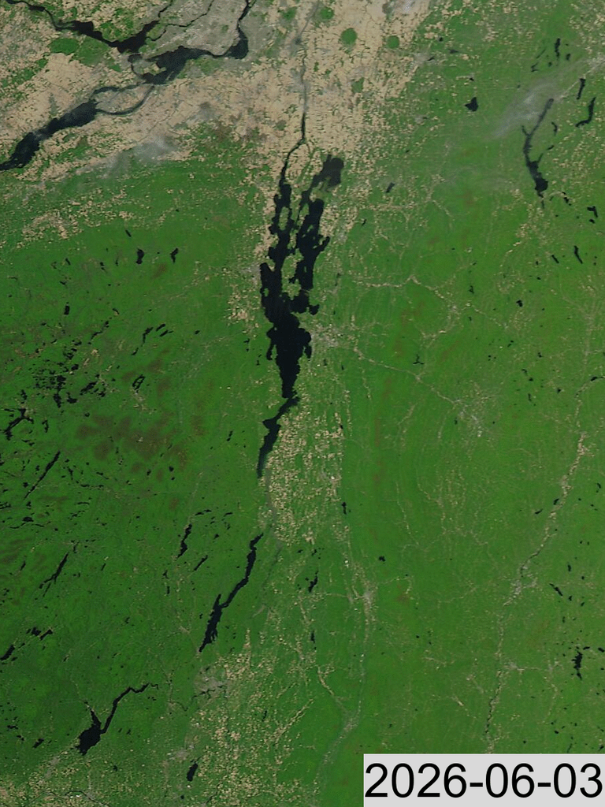